# PYTHON TUTORIAL

### 4.1.3 Lists

In Python, lists are used to store multiple data at once. For example,

Suppose we need to record the ages of 5 students. Instead of creating 5 separate variables, we can simply create a list:

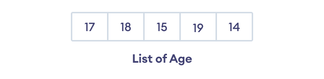

Below are the topics covered for understanding lists in python

- 1.Create a Python List
- 2.Access Python List Elements
- 3.Negative Indexing in Python
- 4.Slicing of a Python List
- 5.Add Elements to a Python List
- 6.Change List Items
- 7.Remove an Item From a List
- 8.Iterating through a List

#### 1:Creating Python List

A list is created in Python by placing items inside [], separated by commas . Different ways of creating list are shown below.For example,

```python
# Example 1 : Creating list with 3 integers
numbers = [1, 7, 5]

# Example 2 : Creating an empty list
my_list = []

# Example 3: List with mixed data types
my_list = [1, "Hello", 3.4]

#Example 4   # Creating string list
names=["Jeff", "Bill", "Steve", "Mohan"]
```

#### 2:Access Python List Elements

You can think of a list as a relationship between indexes and values. This relationship is called a mapping; each index maps to one of the values. The indexes for the values in a list are illustrated as below

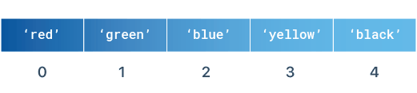

```python
#Creating the List L
L = ['red', 'green', 'blue', 'yellow', 'black']

print(L[0])
# Prints red

print(L[2])
# Prints blue

#print(L[10])
# Triggers IndexError: list index out of range
```

```
red
blue
```

- Note:Python will raise an IndexError error, if you use an index that exceeds the number of items in your list.

Example print(L[10]) will print error as Triggers IndexError: list index out of range

#### 3:Negative Indexing in Python

Python allows negative indexing for its sequences. The index of -1 refers to the last item, -2 to the second last item and so on.

Let's see an example,

```python
languages = ["Python", "Swift", "C++"]

# access item at index 0
print(languages[-1])   # C++

# access item at index 2
print(languages[-3])   # Python
```

#### 4:Slicing of a Python List

In Python it is possible to access a section of items from the list using the slicing operator :, not just a single item. For example,

```python
# List slicing in Python

my_list = ['p','r','o','g','r','a','m','i','n','g']
# index -->[0   1   2   3   4   5   6    7   8   9]
# items from index 2 to index 4
print(my_list[2:5])

# items from index 5 to end
print(my_list[5:])

# items beginning to end
print(my_list[:])
```

```
['o', 'g', 'r']
['a', 'm', 'i', 'n', 'g']
['p', 'r', 'o', 'g', 'r', 'a', 'm', 'i', 'n', 'g']
```

#### 5:Add Elements to a Python Listt

Python List provides different methods to add items to a list.

- 1. Using append()
- 1. Using extend()

###### Using append()

The append() method adds an item at the end of the list. For example,

```python
numbers = [21, 44, 64, 12]
print("Before Append:", numbers)

# using append method note->append() add 32 to the list
numbers.append(32)

print("After Append:", numbers)
```

```
Before Append: [21, 44, 64, 12]
After Append: [21, 44, 64, 12, 32]
```

###### Using extend()

extend() method to add all items of one list to another. For example

```python
prime_numbers = [2, 3, 5]
print("List1:", prime_numbers)

even_numbers = [4, 6, 8]
print("List2:", even_numbers)

# join two lists
prime_numbers.extend(even_numbers)

print("List after append:", prime_numbers)
```

```
List1: [2, 3, 5]
List2: [4, 6, 8]
List after append: [2, 3, 5, 4, 6, 8]
```

The summarization of above is listed below

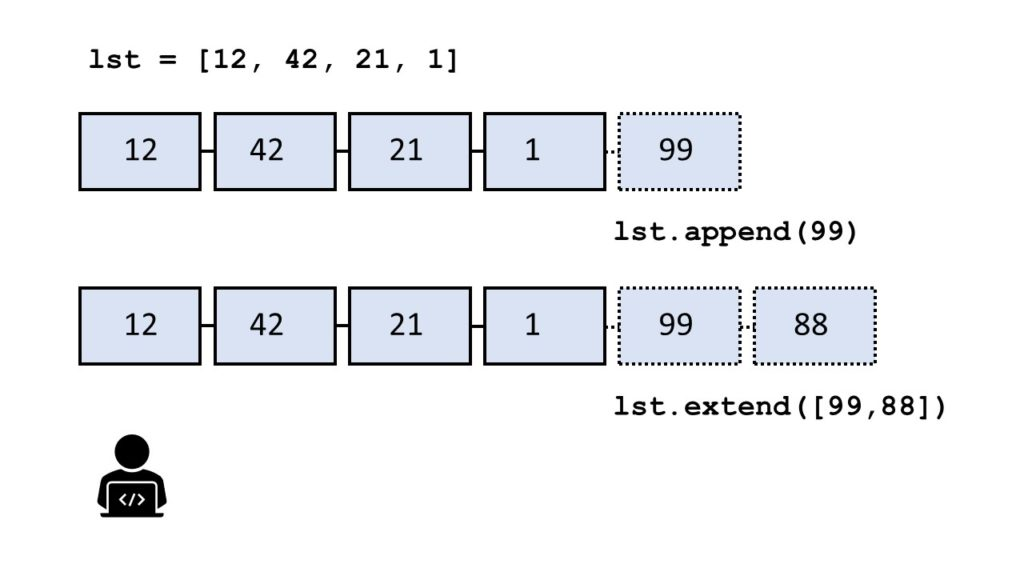

#### 6:Changing List items

Python lists are mutable. Meaning lists are changeable. And, we can change items of a list by assigning new values using = operator. For example,

```python
word = ['A', 'B', 'C']

# changing the third item to 'D'
word[2] = 'D'

print(word)  # ['A', 'B', 'D']
```

```
['A', 'B', 'D']
```

#### 7:Remove an Item From a List

#### 1: Using del()

In Python we can use the del statement to remove one or more items from a list. For example

```python
word = ['A', 'B', 'C', 'D', 'E', 'F', 'G']
#index->[0    1    2    3    4    5    6 ]

#I have mapeed the indexing of list for understanding

# deleting the second item
del word[1]
print(word) # ['A', 'C', 'D', 'E', 'F', 'G']

# deleting the last item
del word[-1]
print(word) # ['A', 'C', 'D', 'E', 'F']

# delete first two items
del word[0 : 2]  # ['D', 'E', 'F']
print(word)
```

```
['A', 'C', 'D', 'E', 'F', 'G']
['A', 'C', 'D', 'E', 'F']
['D', 'E', 'F']
```

#### 2:using remove

```python
#consider the example below
languages = ['Python', 'Swift', 'C++', 'C', 'Java', 'Rust', 'R']
# remove 'Python' from the list
languages.remove('Python')

print(languages) # ['Swift', 'C++', 'C', 'Java', 'Rust', 'R']
```

```
['Swift', 'C++', 'C', 'Java', 'Rust', 'R']
```

Note Here, languages.remove('Python') removes 'Python' from the languages list.

#### 7:Iterating through a List

We can use the for loop to iterate over the elements of a list. The more understanding of the loops is explained later in the tutorial in detail.

# A loop is used for iterating over a sequence (that is either a list, a tuple, a dictionary, a set, or a string)

For example,

```python
# We can use the for loop to iterate over the elements of a list. For example,

word = ['A', 'B', 'C']

# iterating through the list
for var in word:
    print(var)
```

```
A
B
C
```

Code Explanation-The exceution of the flow is explained below in our case the list name is word .

[figure not shown]

### 4.1.3 Tuples

A Python tuple is an immutable ordered sequence of items. In other words, existing objects in the sequence cannot be modified, and new elements cannot be added once the sequence is created. A tuple consists of several values separated by commas. Unlike a Python list, tuples are enclosed within parentheses “( )”. We are covering the below topics in Tuple.

- 1.Features of Python Tuple
- 2.Creating of Tuple:
- 3.Accessing Tuple Elements
- 4.Slicing
- 5.Deleting a Tuple
- 6.Iterating Through a Tuple
- 7.Advantages of Tuple over List in Python
- 8.Differences Between Lists and Tuples

#### 1:Features of Python Tuple

- Tuples are an immutable data type, which means that once they have been generated, their elements cannot be changed.
- Since tuples are ordered sequences, each element has a specific order that will never change.

#### 2:Creating Tuple

To create a tuple, all the objects (or "elements") must be enclosed in parenthesis (), each one separated by a comma. Although it is not necessary to include parentheses, doing so is advised.

A tuple can contain any number of items, including ones with different data types (dictionary, string, float, list, etc.) Below are the examples.

```python
# Python program to show how to create a tuple
# Example1 :Creating an empty tuple
empty_tuple = ()
print("Example1 :Creating the Empty tuple-> ", empty_tuple)

# Example2 :Creating tuple having integers
int_tuple = (4, 6, 8, 10, 12, 14)
print("Example2 :Tuple with integers-> ", int_tuple)

# Example3 :Creating a tuple having objects of different data types
mixed_tuple = (4, "Python", 9.3)
print("Example3 : Tuple with different data types-> ", mixed_tuple)

#Example4 : Creating a nested tuple
nested_tuple = ("Python", {4: 5, 6: 2, 8:2}, (5, 3, 5, 6))
print("Example4 : A nested tuple-> ", nested_tuple)

#Example 5 :Creating tuple without parentheses
my_tuple = 1, 2, 3
print("Example5 : A tuple without parentheses -> ", my_tuple)
```

```
Example1 :Creating the Empty tuple->  ()
Example2 :Tuple with integers->  (4, 6, 8, 10, 12, 14)
Example3 : Tuple with different data types->  (4, 'Python', 9.3)
Example4 : A nested tuple->  ('Python', {4: 5, 6: 2, 8: 2}, (5, 3, 5, 6))
Example5 : A tuple without parentheses ->  (1, 2, 3)
```

##### Code Explanation

In the above example, we have created different types of tuples and stored different data items inside them.

- NOTE 1 :In the example 4 we have stored{{4: 5, 6: 2, 8:2} in tuple which is a dictionary about which we will study later.
- NOTE 2 :As mentioned earlier, we can also create tuples without using parentheses shown in example 5

#### Create a Python Tuple With one Elementt

In Python, creating a tuple with one element is a bit tricky. Having one element within parentheses is not enough.

We will need a trailing comma to indicate that it is a tuple,Below is the example

```python
var_1 = ("Hello") # string
var_2 = ("Hello",) # tuple
var_3 = "hello",

#We can use the type() function to know which class a variable or a value belongs to.We can check for the above variable as shown below
print("The type of the var_1 is -->  ", type(var_1))  # <class 'str'>
print("The type of the var_2 is -->  ",type(var_2))  # <class 'tuple'>
print("The type of the var_3 is -->  ",type(var_3))  # <class 'tuple'>
```

```
The type of the var_1 is -->   <class 'str'>
The type of the var_2 is -->   <class 'tuple'>
The type of the var_3 is -->   <class 'tuple'>
```

##### Code Explanation

```python
# Here,
# ("hello") is a string so type() returns str as class of var_1 i.e. <class 'str'>
# ("hello",) and "hello", both are tuples so type() of var_2 and var_3 is of .<class 'tuple'>
```

#### 3:Access Python Tuple Elements

The process of accessing elements from a tuple, works similar to strings and lists.

You can access individual elements of a tuple using indexing and a range of elements using slicing. In Python tuples, index starts from 0 and keeps increasing by 1 with every element in the tuple. This is called Positive Indexing(or indexing from the beginning). If there are n elements in a tuple, the 1st element will have index of 0 and the last element will have index n-1.

Python also allows negative indexing of tuples(indexing from the end). If there are n elements in a list, the last element will have index of -1 and the first element will have index -n.

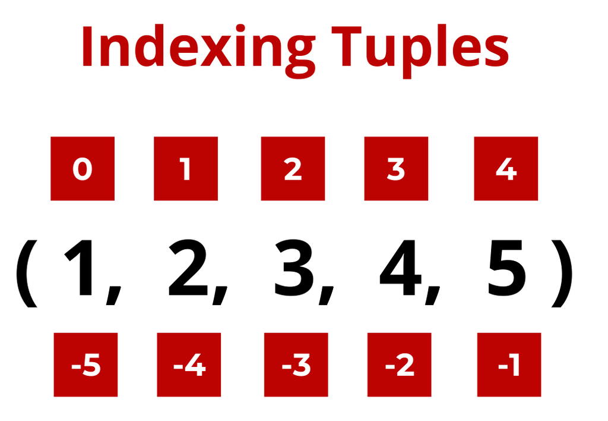